# Total_SC

April Peterson

09 January 2020

# Goals

Why include these results in the Main MLH1 results?

- test if **greater SC area in females is a conserved trait of heterochiasmy**
- test how average total SC correlates / contributes to mean CO

## Discribe these Data

output from RW SC_skel run over Anon_Data images. The file names are random

## Running the Python Script

Python – apply to all images in the Anon folder (so all the random named image files)

(should I update all the crops? How many images need cropping)

### ToDo

- How will I test these / and adjust for XX?
- Look up the python output
- Check for outliers in the skel data
- rerun the Python scrip

ToDo re-run the pipeline, to get measues for SKIVE and MOLF females molf has almost eq SC – but this is just 1 female

merge the sc.skel outputs with the master MLH1 measures match up random names with original names

the skel output and scripts are in the SC_skel dir. it was run on all images in the anon_data folder. I haven’t manually confirmed that the default parameters are skeletonizing the images correctly.

# More Analysis

I noticed that these cells have the same bin sizes and skel sizes this is written within RW’s code

now there are quite a few cells above the threshold table(Total.SC.above.threshold$category) more female cells than male

remove outliers MLH1.merge.Skel <- MLH1.merge.Skel[MLH1.merge.Skel$skel_size < 25000,] try with subset

to clean up the total SC data – use the images with no in redo crop (400 vs 2500) could also compare to quality =1 cells

test if my score of crop, causes more noise / is a cleaner cell segment for internal checking, not need to keep

make tables of the means ect to measure how much change there is between these subseted data sets

```
##
##    WSB female      WSB male      G female        G male    LEW female
##           216           130           252           220           126
##      LEW male     PERC male    PWD female      PWD male    MSM female
##           180            28           192           124           234
##      MSM male   MOLF female     MOLF male  SKIVE female    SKIVE male
##           112             0            24             0            55
##    KAZ female      KAZ male  CZECH female    CZECH male      AST male
##           111           177             0             8            52
##      TOM male   CAST female     CAST male    HMI female      HMI male
##             0             1            30             0            50
##  SPRET female    SPRET male   SPIC female     SPIC male CAROLI female
##            12            99           115            44             0
##   CAROLI male            F1         other
##            34            19             0
```

```
##
##    WSB female      WSB male      G female        G male    LEW female
##           230           160           323           315           197
##      LEW male     PERC male    PWD female      PWD male    MSM female
##           299            31           257           177           343
##      MSM male   MOLF female     MOLF male  SKIVE female    SKIVE male
##           182             9            29             6            58
##    KAZ female      KAZ male  CZECH female    CZECH male      AST male
##           116           228             0            12            53
##      TOM male   CAST female     CAST male    HMI female      HMI male
##             0             1            56             0            77
##  SPRET female    SPRET male   SPIC female     SPIC male CAROLI female
##            15           119           129           106             0
##   CAROLI male            F1         other
##            34            22             0
```

table of clean crop stat table of total (minus clean crop, stat) difference in means is the amount of error

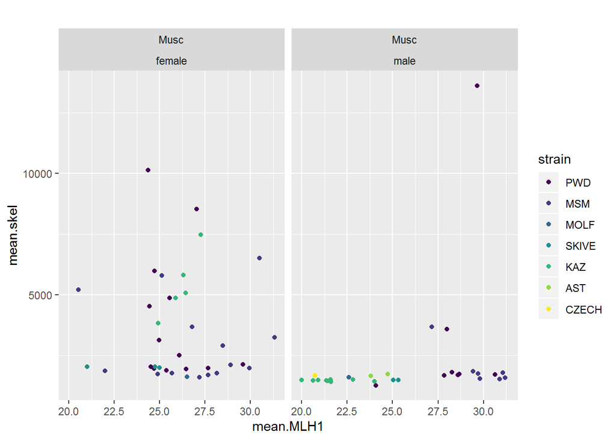

double check a way to visually inspect the python skel output

repeat random numbers?

some of richard’s analysis show negative relationship with SC length and MLH1 (his QTL word doc). Could this be sign of pwd like regulation?

remove MLH1 tables since they overwrite other ones

remove plots, tables for internal checking what to keep: SC.skel, OG.MLH1.merge.Skel, MLH1.merge.Skel, MLH1.merge.Skel.DUPs, mouse.level.skel